# Unsupervised Learning in Python

*Some datasets provided by DataCamp.com*

# Clustering with KMeans

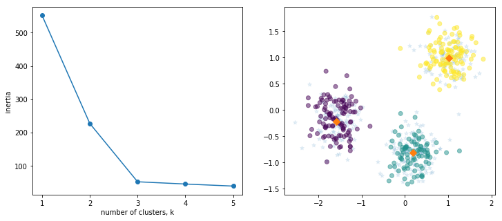

```python
import pandas as pd
from sklearn.cluster import KMeans
import matplotlib.pyplot as plt

df = pd.read_csv('points.csv',sep=';',header=None)
points = df.as_matrix()

df2 = pd.read_csv('new_points.csv',sep=';',header=None)
new_points = df2.as_matrix()

ks = range(1,6)
inertias=[] # Sum of distances of samples to their closest cluster center.

for i in ks:
    model = KMeans(n_clusters=i)
    model.fit(points)
    inertias.append(model.inertia_)

plt.figure(figsize=(12,5))
plt.subplot(1,2,1)
plt.plot(ks,inertias,'-o') # elbow at n_clusters=3
plt.xlabel('number of clusters, k')
plt.ylabel('inertia')
plt.xticks(ks)

clust = KMeans(n_clusters=3)
clust.fit(points)

x = points[:,0]
y = points[:,1]

plt.subplot(1,2,2)
plt.scatter(x,y,marker='*',alpha=0.1)

labels = clust.predict(new_points)

xs = new_points[:,0]
ys = new_points[:,1]

plt.scatter(xs,ys,c=labels,alpha=0.5)

centroids = clust.cluster_centers_

centroids_x = centroids[:,0]
centroids_y = centroids[:,1]

plt.scatter(centroids_x,centroids_y,marker='D',s=50)

plt.show()
```

**Clustering - iris dataset**

```
(150, 4) [ 0.82530129  0.43214658  1.75852918  0.76061262]
```

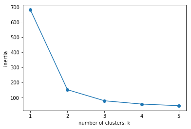

```
varieties   0   1   2
labels
0           0  48  14
1          50   0   0
2           0   2  36
```

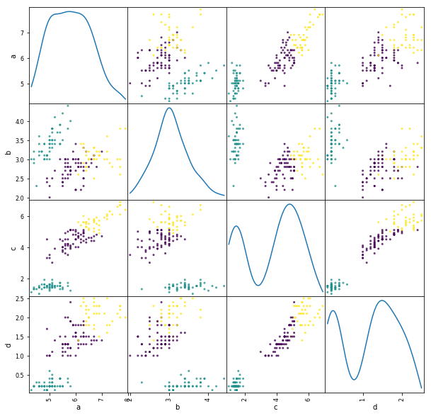

```python
from sklearn import datasets
import pandas as pd
from sklearn.cluster import KMeans
import matplotlib.pyplot as plt
import numpy as np
from sklearn.preprocessing import scale

iris = datasets.load_iris()
X = iris.data
y = iris.target

#X = scale(X) # in this case, scaling doesn't improve results!

print(X.shape, np.std(X,axis=0))

ks = range(1,6)
inertias=[]

for i in ks:
    model = KMeans(n_clusters = i)
    model.fit(X)
    inertias.append(model.inertia_)

plt.plot(ks,inertias,'-o')
plt.xlabel('number of clusters, k')
plt.ylabel('inertia') #  within-cluster sum of squares criterion
plt.xticks(ks)
plt.show()  # elbow at n_clusters=3

clust = KMeans(n_clusters = 3)
labels = clust.fit_predict(X)

df = pd.DataFrame({'labels': labels, 'varieties': y})
ct = pd.crosstab(df['labels'],df['varieties'])

print(ct)

from pandas.plotting import scatter_matrix
df = pd.DataFrame(X, columns=['a', 'b', 'c', 'd'])
scatter_matrix(df, alpha=0.8, figsize=(10, 10), diagonal='kde',c=labels)
plt.show()
```

**Clustering - fish dataset**

```
species  Bream  Pike  Roach  Smelt
labels
0            0    17      0      0
1           33     0      1      0
2            0     0      0     13
3            1     0     19      1
(85, 6)
```

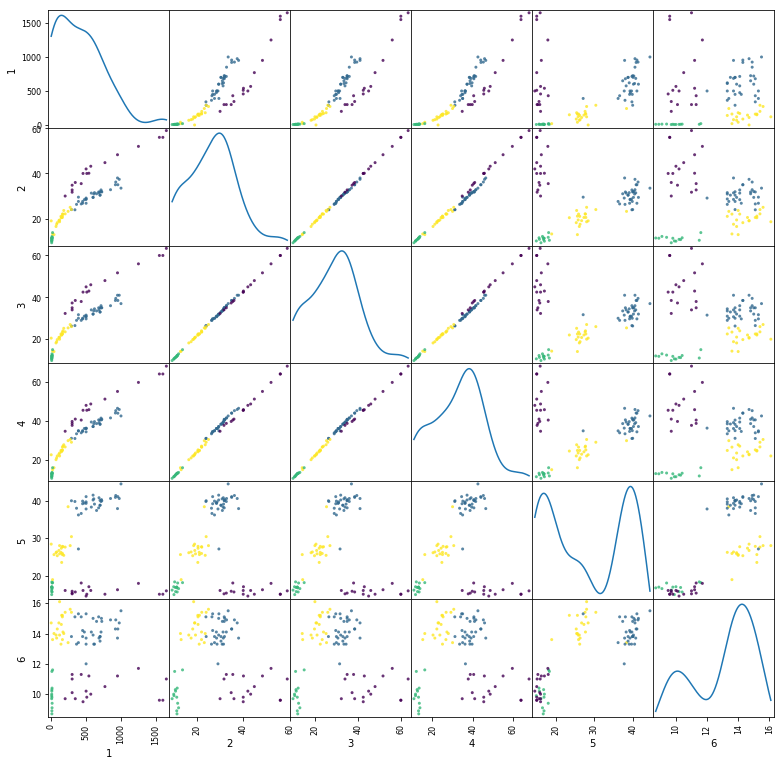

```python
# clustering of fish data
# Samples giving measurements of fish. Each row represents an individual fish. Measurements have very different scales.

from sklearn.pipeline import make_pipeline
from sklearn.preprocessing import StandardScaler
from sklearn.cluster import KMeans
import pandas as pd

df = pd.read_csv('fish.csv',header=None)
species = df.iloc[:,0]
fish_data = df.iloc[:,1:]

# Create scaler: scaler
scaler = StandardScaler()

# Create KMeans instance: kmeans
kmeans = KMeans(n_clusters=4)

# Create pipeline: pipeline
pipeline = make_pipeline(scaler,kmeans)

pipeline.fit(fish_data)

labels = pipeline.predict(fish_data)

df = pd.DataFrame({'labels':labels,'species':species})

ct = pd.crosstab(df['labels'],df['species'])

print(ct)

print(fish_data.shape)
from pandas.plotting import scatter_matrix
scatter_matrix(fish_data, alpha=0.8, figsize=(13, 13), diagonal='kde',c=labels)
plt.show()
```

**Clustering stocks**

```python
# Daily price movements of stocks of different companies from 2010 to 2015.
# where each row corresponds to a company, and each column corresponds to a trading day.

import pandas as pd
from sklearn.pipeline import make_pipeline
from sklearn.preprocessing import Normalizer
from sklearn.cluster import KMeans
from sklearn.manifold import TSNE

df = pd.read_csv('company-stock-movements-2010-2015.csv')
companies = df.iloc[:,0].values
movements = df.iloc[:,1:].values
print('Movements array shape: {}\n'.format(movements.shape))

normalizer = Normalizer() # rescales each sample - here, each company's stock price - independently of the other.

kmeans = KMeans(n_clusters=10)
pipeline = make_pipeline(normalizer,kmeans)
pipeline.fit(movements)
labels=pipeline.predict(movements)
df = pd.DataFrame({'labels': labels, 'companies': companies})
print(df.sort_values('labels'))
```

```
Movements array shape: (60, 963)

                             companies  labels
22                                  HP       0
24                               Intel       0
51                   Texas instruments       0
33                           Microsoft       0
14                                Dell       0
11                               Cisco       0
47                            Symantec       1
43                                 SAP       1
19                     GlaxoSmithKline       1
49                               Total       1
37                            Novartis       1
46                      Sanofi-Aventis       1
```

[output cut: 48 more lines]

# Hierarchical clustering

**Clustering stocks**

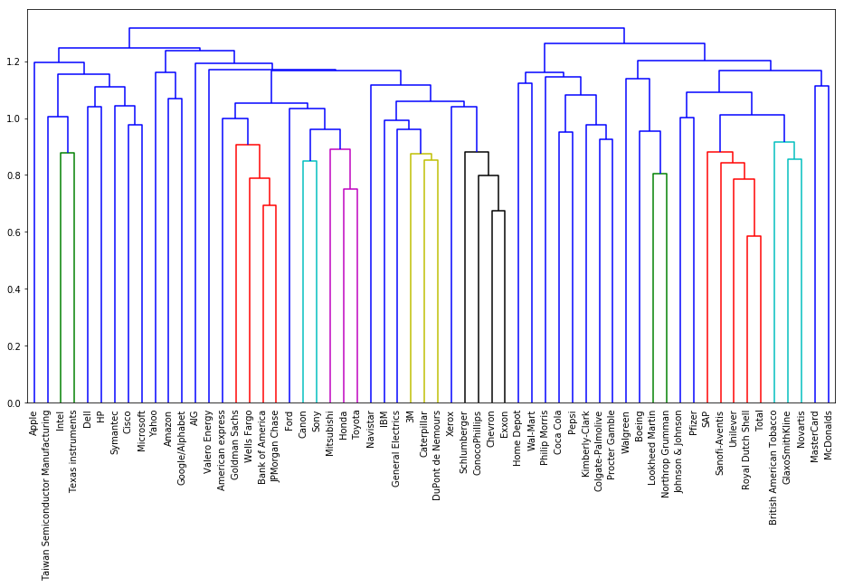

```
                             companies  labels
51                   Texas instruments       1
50  Taiwan Semiconductor Manufacturing       1
24                               Intel       1
22                                  HP       2
14                                Dell       2
47                            Symantec       3
33                           Microsoft       3
11                               Cisco       3
0                                Apple       4
2                               Amazon       5
17                     Google/Alphabet       5
59                               Yahoo       6
7                                Canon       7
34                          Mitsubishi       7
```

[output cut: 46 more lines]

```python
# SciPy hierarchical clustering doesn't fit into a sklearn pipeline, so we use the normalize() function

from scipy.cluster.hierarchy import linkage, dendrogram, fcluster
import matplotlib.pyplot as plt
from sklearn.preprocessing import normalize
import pandas as pd

df = pd.read_csv('company-stock-movements-2010-2015.csv')
companies = df.iloc[:,0].values
movements = df.iloc[:,1:].values

normalized_movements = normalize(movements)
# Calculate the linkage: mergings
mergings = linkage(normalized_movements,method='complete')

# Plot the dendrogram
plt.figure(figsize=(16, 8))
dendrogram(mergings,labels=companies,leaf_rotation=90,leaf_font_size=10,)
plt.show()

# f cluster to extract cluster labels at height 1.1
labels = fcluster(mergings,1.1,criterion='distance')
df = pd.DataFrame({'labels': labels, 'companies': companies})
print(df.sort_values('labels'))
```

**Clustering grain samples**

```python
from scipy.cluster.hierarchy import linkage, dendrogram, fcluster
import matplotlib.pyplot as plt
import pandas as pd
from scipy.cluster.hierarchy import fcluster

df = pd.read_csv('seeds.csv',header=None)
varieties = df.iloc[:,-1]
samples_grain = df.iloc[:,:-1].values

varieties = varieties.astype('category')
varieties.cat.categories = ['Kama wheat','Rosa wheat','Canadian wheat']

mergings = linkage(samples_grain, method='complete')

# f cluster to extract cluster labels at height 6
labels = fcluster(mergings,8,criterion='distance')

df = pd.DataFrame({'labels': labels, 'varieties': varieties})

ct = pd.crosstab(df['labels'],df['varieties'])

print(ct)
```

```
varieties  Kama wheat  Rosa wheat  Canadian wheat
labels
1                   0          47               0
2                  52          23               0
3                  18           0              70
```

# t-SNE

**t-SNE with iris dataset**

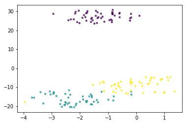

```python
# t-SNE (t-distributed stochastic neighbor embedding) allows visualization of high dimensional datasets in 2D.
# every time we run it, the clusters appear in different positions respect to the axis (but same to one another)

import matplotlib.pyplot as plt
from sklearn import datasets
from sklearn.manifold import TSNE

iris = datasets.load_iris()
samples = iris.data
labels = iris.target

model = TSNE(learning_rate = 200) # learning rate btw 50 and 200
tsne_features = model.fit_transform(samples)
xs = tsne_features[:,0]
ys = tsne_features[:,1]

plt.scatter(xs,ys,c=labels,s=10,alpha=0.7)
plt.show()
```

**t-SNE with stock data**

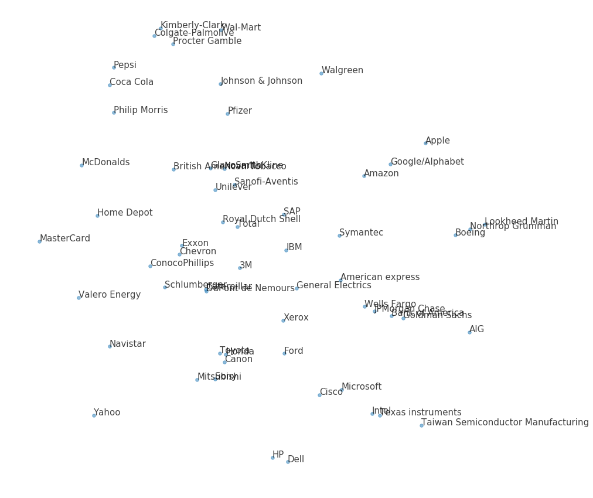

```python
from sklearn.preprocessing import normalize
import matplotlib.pyplot as plt
from sklearn import datasets
from sklearn.manifold import TSNE

df = pd.read_csv('company-stock-movements-2010-2015.csv')
companies = df.iloc[:,0].values
movements = df.iloc[:,1:].values

normalized_movements = normalize(movements)

model = TSNE(learning_rate = 50) # learning rate btw 50 and 200
tsne_features = model.fit_transform(normalized_movements)
xs = tsne_features[:,0]
ys = tsne_features[:,1]

plt.figure(figsize=(15, 15))
plt.scatter(xs,ys,alpha=0.5,s=30)
for x, y, company in zip(xs, ys, companies):
    plt.annotate(company, (x, y), fontsize=15, alpha=0.75)
plt.axis('off')
plt.show()
```

# PCA (Principal Component Analysis)

```
Correlation before PCA: 0.8604149377143467
Correlation after PCA: 9.966209199270724e-17
First Principal Component: [ 0.63910027  0.76912343].
We see that PCA manages to decorrelate the two features.
```

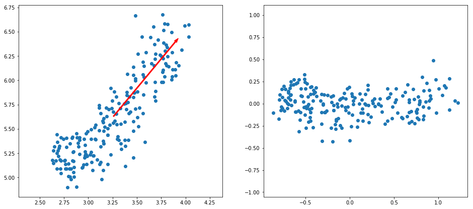

```python
import numpy as np
from sklearn.decomposition import PCA
import matplotlib.pyplot as plt
from scipy.stats import pearsonr
import pandas as pd

df = pd.read_csv('seeds2.csv',header=None)

grains = df.values
width = df.iloc[:,0].values
length = df.iloc[:,1].values

plt.figure(figsize=(16, 7))
plt.subplot(121)
plt.scatter(width, length)
plt.axis('equal')  # preserve aspect ratio

correlation, pvalue = pearsonr(width,length)
print('Correlation before PCA: {}'.format(correlation))

model = PCA()
pca_features = model.fit_transform(grains)
x_pca = pca_features[:,0]
y_pca = pca_features[:,1]

# plot arrow
mean = model.mean_
first_pc = model.components_[0,:]
plt.arrow(mean[0], mean[1], first_pc[0], first_pc[1], color='red', width=0.01)

correlation2, pvalue2 = pearsonr(x_pca,y_pca)
print('Correlation after PCA: {}'.format(correlation2))
print('First Principal Component: {}.'.format(first_pc))
print('We see that PCA manages to decorrelate the two features.')

plt.subplot(122)
plt.scatter(x_pca, y_pca)
plt.axis('equal')
plt.show()
```

**PCA with fish dataset**

```
Dataset dimensions: (85, 6)
6 features
```

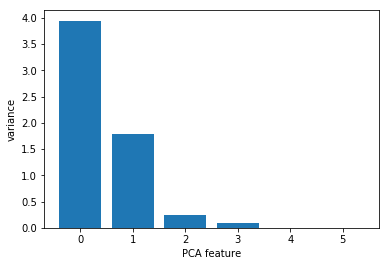

```
Intrinsic dimension: 2
PCA features: (85, 2)
```

```python
from sklearn.decomposition import PCA
from sklearn.preprocessing import StandardScaler
from sklearn.pipeline import make_pipeline
import matplotlib.pyplot as plt

df = pd.read_csv('fish.csv',header=None)
species = df.iloc[:,0].values
fish_data = df.iloc[:,1:].values
print('Dataset dimensions: {}'.format(fish_data.shape))
print('6 features')

scaler = StandardScaler()
pca = PCA()
pipeline = make_pipeline(scaler,pca)
pipeline.fit(fish_data)

# Plot the explained variances
features = range(pca.n_components_)
plt.bar(features, pca.explained_variance_)
plt.xlabel('PCA feature')
plt.ylabel('variance')
plt.xticks(features)
plt.show()

print('Intrinsic dimension: {}'.format(2))

# Reduce to 2 dimensions
pca = PCA(n_components=2)
pipeline = make_pipeline(scaler,pca)
pca_features = pipeline.fit_transform(fish_data)
print('PCA features: {}'.format(pca_features.shape))
```

# tf-idf (word-frequency array)

```python
# tf-idf (term frequency - inverse document frequency)
# reflect how important a word is to a document in a collection or corpus.
# term frequency account for the frequency of a word in a document
# inverse document frequency accounts for the ratio of documents that include a specific word
# they are CSR matrices (Compressed Sparse Row matrix)

documents = ['cats say meow', 'dogs say woof', 'dogs chase cats']

from sklearn.feature_extraction.text import TfidfVectorizer

tfidf = TfidfVectorizer()
csr_mat = tfidf.fit_transform(documents)

print(csr_mat.toarray())
words = tfidf.get_feature_names()
print(words)
```

```
[[ 0.51785612  0.          0.          0.68091856  0.51785612  0.        ]
 [ 0.          0.          0.51785612  0.          0.51785612  0.68091856]
 [ 0.51785612  0.68091856  0.51785612  0.          0.          0.        ]]
['cats', 'chase', 'dogs', 'meow', 'say', 'woof']
```

## *Clustering Wikipedia articles*

*With the tf-idf of the articles, we perform singular value decomposition to reduce dimension to 50 components. We then perform clustering with KMeans.*

```python
# We will cluster 60 Wikipedia articles in 6 clusters
# articles: tf-idf word-frequencies of some popular Wikipedia articles.
# sparse matrix of type '<class 'numpy.float64' with 42091 stored elements in Compressed Sparse Row format>
# scikit-learn PCA cannot work with sparse CSR matrices. For this purpose, we use truncated svd.

from sklearn.decomposition import TruncatedSVD
from sklearn.cluster import KMeans
from sklearn.pipeline import make_pipeline
import pandas as pd
from scipy import sparse

# Read tf-idf from csv file (vocabulary of 13125 words)
df = pd.read_csv('wikipedia-vectors.csv',index_col=0)
titles = df.columns
print(titles)
print("\n",df.shape)

articles = df.as_matrix().transpose()
articles = sparse.csr_matrix(articles)
print("\ntf-idf dimensions: {}".format(articles.shape))

# Reduce dimension to 50 components (50 most representative words)
svd = TruncatedSVD(n_components=50)
# KMeans clustering
kmeans = KMeans(n_clusters=6)
pipeline = make_pipeline(svd,kmeans)
pipeline.fit(articles)
labels = pipeline.predict(articles)
df = pd.DataFrame({'label': labels, 'article': titles})
#print(df.sort_values('label'))
grouped = df.groupby('label')
for name, group in grouped:
    print('\nGroup' + str(name))
    print(group.article.values)
```

```
Index(['HTTP 404', 'Alexa Internet', 'Internet Explorer', 'HTTP cookie',
       'Google Search', 'Tumblr', 'Hypertext Transfer Protocol',
       'Social search', 'Firefox', 'LinkedIn', 'Global warming',
       'Nationally Appropriate Mitigation Action', 'Nigel Lawson',
       'Connie Hedegaard', 'Climate change', 'Kyoto Protocol', '350.org',
       'Greenhouse gas emissions by the United States',
       '2010 United Nations Climate Change Conference',
       '2007 United Nations Climate Change Conference', 'Angelina Jolie',
       'Michael Fassbender', 'Denzel Washington', 'Catherine Zeta-Jones',
       'Jessica Biel', 'Russell Crowe', 'Mila Kunis', 'Dakota Fanning',
       'Anne Hathaway', 'Jennifer Aniston', 'France national football team',
       'Cristiano Ronaldo', 'Arsenal F.C.', 'Radamel Falcao',
       'Zlatan Ibrahimović', 'Colombia national football team',
       '2014 FIFA World Cup qualification', 'Football', 'Neymar',
       'Franck Ribéry', 'Tonsillitis', 'Hepatitis B', 'Doxycycline',
       'Leukemia', 'Gout', 'Hepatitis C', 'Prednisone', 'Fever', 'Gabapentin',
       'Lymphoma', 'Chad Kroeger', 'Nate Ruess', 'The Wanted', 'Stevie Nicks',
       'Arctic Monkeys', 'Black Sabbath', 'Skrillex', 'Red Hot Chili Peppers',
       'Sepsis', 'Adam Levine'],
      dtype='object')

 (13125, 60)

tf-idf dimensions: (60, 13125)

Group0
['Chad Kroeger' 'Nate Ruess' 'The Wanted' 'Stevie Nicks' 'Arctic Monkeys'
 'Black Sabbath' 'Skrillex' 'Red Hot Chili Peppers' 'Sepsis' 'Adam Levine']

Group1
['Tonsillitis' 'Hepatitis B' 'Doxycycline' 'Leukemia' 'Gout' 'Hepatitis C'
 'Prednisone' 'Fever' 'Gabapentin' 'Lymphoma']

Group2
['Angelina Jolie' 'Michael Fassbender' 'Denzel Washington'
 'Catherine Zeta-Jones' 'Jessica Biel' 'Russell Crowe' 'Mila Kunis'
 'Dakota Fanning' 'Anne Hathaway' 'Jennifer Aniston']

Group3
['Global warming' 'Nationally Appropriate Mitigation Action' 'Nigel Lawson'
 'Connie Hedegaard' 'Climate change' 'Kyoto Protocol' '350.org'
 'Greenhouse gas emissions by the United States'
 '2010 United Nations Climate Change Conference'
 '2007 United Nations Climate Change Conference']

Group4
['France national football team' 'Cristiano Ronaldo' 'Arsenal F.C.'
 'Radamel Falcao' 'Zlatan Ibrahimović' 'Colombia national football team'
 '2014 FIFA World Cup qualification' 'Football' 'Neymar' 'Franck Ribéry']

Group5
['HTTP 404' 'Alexa Internet' 'Internet Explorer' 'HTTP cookie'
 'Google Search' 'Tumblr' 'Hypertext Transfer Protocol' 'Social search'
 'Firefox' 'LinkedIn']
```

# NMF : Non-negative matrix factorization

### NMF with wikipedia articles

```python
# Like PCA, reduces number of dimensions. The values of the array need to be non-negative
# features extracted are interpretable: documents as combination of topics, images as combinations of common patterns.
# Multiplying the matrix of components with the matrix of features yields an approximation of the original sumples.
# Like PCA, fit & transform methods

from sklearn.decomposition import NMF
import pandas as pd

# Read tf-idf from csv file (vocabulary of 13125 words)
df = pd.read_csv('wikipedia-vectors.csv',index_col=0)
titles = df.columns
articles = df.as_matrix().transpose()
articles = sparse.csr_matrix(articles)

model = NMF(n_components=6)  # we always need to specify the # of components.
model.fit(articles)
nmf_features = model.transform(articles)

# Print the NMF features shape
print("NMF features shape: {}".format(nmf_features.shape))  # 60 articles - 6 components

df = pd.DataFrame(nmf_features,index=titles)
# Print the row for 'Anne Hathaway'
print('\nNMF features for Anne Hathaway:')
print(df.loc['Anne Hathaway'])
# Print the row for 'Denzel Washington'
print('\nNMF features for Denzel Washington:')
print(df.loc['Denzel Washington'])

# the highest component for both is the third! Let's see why:

df = pd.read_csv('wikivocabulary.txt', sep=" ", header=None)
words = df.iloc[:,0].values.tolist()
components_df = pd.DataFrame(model.components_,columns=words)
print("\nComponents: {}".format(components_df.shape))
# Select row 3: component
component = components_df.iloc[3,:]
# Print result of nlargest
print("\nMost important words for the third component:\n{}".format(component.nlargest()))
print("\nWe see that the third component refers to the topic CINEMA.")
print("\nComponents correspond to topics of documents and the NMF features reconstruct the documents from the topics.")
# -> the third component refers to the topic CINEMA.
# Components correspond to topics of documents and the NMF features reconstruct the documents from the topics.
```

```
NMF features shape: (60, 6)

NMF features for Anne Hathaway:
0    0.003845
1    0.000000
2    0.000000
3    0.575663
4    0.000000
5    0.000000
Name: Anne Hathaway, dtype: float64

NMF features for Denzel Washington:
0    0.000000
1    0.005601
2    0.000000
3    0.422345
4    0.000000
5    0.000000
Name: Denzel Washington, dtype: float64

Components: (6, 13125)

Most important words for the third component:
film       0.627928
award      0.253152
starred    0.245304
role       0.211468
actress    0.186413
Name: 3, dtype: float64

We see that the third component refers to the topic CINEMA.

Components correspond to topics of documents and the NMF features reconstruct the documents from the topics.
```

### NMF with digits dataset

```
Dimensions of dataset (100, 104)
```

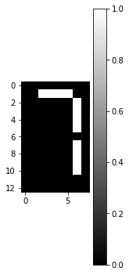

```
NMF Components:
```

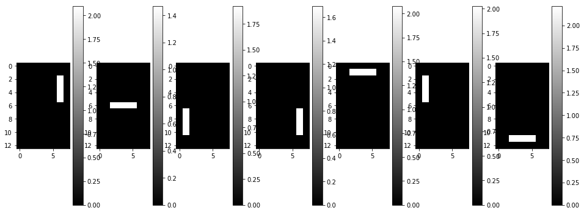

```
NMF features of the digit above (7): [  4.76823559e-01   0.00000000e+00   0.00000000e+00   5.90605054e-01
   4.81559442e-01   0.00000000e+00   7.37546142e-16]


PCA Components:
```

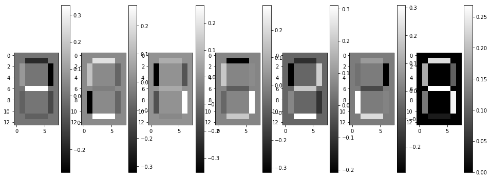

```python
from matplotlib import pyplot as plt
import numpy as np
from sklearn.decomposition import NMF
import pandas as pd

df = pd.read_csv('digits.csv',header=None)
digits = df.values
print("Dimensions of dataset {}".format(digits.shape))

def show_as_image(i,sample):
    bitmap = sample.reshape((13, 8))
    ind = 171 + i
    plt.subplot(ind)
    plt.imshow(bitmap, cmap='gray', interpolation='nearest')
    plt.colorbar()

# Select the 0th row: digit0
digit0 = digits[0,:]
plt.figure(figsize=(16, 7))
show_as_image(0,digit0)
plt.show()

model = NMF(n_components=7)
features = model.fit_transform(digits)

print("NMF Components:")
plt.figure(figsize=(16, 7))
for i,component in enumerate(model.components_):
    show_as_image(i,component)
plt.show()

digit_features = features[0,:]
print("\nNMF features of the digit above (7): {}".format(digit_features))



# NMF decomposes grayscale images into their commonly occurring patterns
# PCA on the contrary:

from sklearn.decomposition import PCA
model = PCA(n_components=7)
features = model.fit_transform(digits)
plt.figure(figsize=(16, 7))

print("\n\nPCA Components:")
for i,component in enumerate(model.components_):
    show_as_image(i,component)
plt.show()
```

## Recommender system of wikipedia articles

*Perform NMF with 6 components, normalize them and compute the dot product, this gives us the cosine similarities between articles. To recommend other articles based on a given article, return the articles with the biggest cosine similarities to the given article.*

```python
# wikipedia articles
from sklearn.decomposition import NMF
import numpy as np
import pandas as pd
from sklearn.preprocessing import normalize

# Read tf-idf from csv file (vocabulary of 13125 words)
df = pd.read_csv('wikipedia-vectors.csv',index_col=0)
titles = df.columns
articles = df.as_matrix().transpose()
articles = sparse.csr_matrix(articles)

model = NMF(n_components=6)  # we always need to specify the # of components.
model.fit(articles)
nmf_features = model.transform(articles)

norm_features = normalize(nmf_features)

df = pd.DataFrame(norm_features,index=titles)
article = df.loc['Cristiano Ronaldo'] # we look for articles similar to the one of CR

# Compute the dot products: similarities
similarities = df.dot(article)
similarities2 = similarities[similarities<1]
# dot calculates the matrix product which in this case, since the features are normalized, corresponds to the cosine
# the higher the cosine, the more similar the articles are (same proportion of topics)

# Display those with the largest cosine similarity
print("Other articles similar to Cristiano Ronaldo:\n")
print(similarities2.nlargest(8))
```

```
Other articles similar to Cristiano Ronaldo:

Franck Ribéry                        0.999972
Radamel Falcao                       0.999942
Zlatan Ibrahimović                   0.999942
France national football team        0.999923
Colombia national football team      0.999897
Neymar                               0.999021
2014 FIFA World Cup qualification    0.998443
Arsenal F.C.                         0.997739
dtype: float64
```

## Recommender system of musical artists

*Scale each column (user) by its maximum absolute value (to ensure that all users have the same influence), perform NMF with 20 components, normalize them and compute the dot product. This gives us the cosine similarities between artists. To recommend other artists similar to a given one, return the artists with the largest cosine similarities to the given one.*

```python
import numpy as np
from scipy import sparse
from sklearn.decomposition import NMF
from sklearn.preprocessing import Normalizer, MaxAbsScaler
from sklearn.pipeline import make_pipeline
import pandas as pd

# users_data: sparse array whose rows correspond to artists and whose column correspond to users.
# The entries give the number of times each artist was listened to by each user.

df = pd.read_csv('users_data.csv',header=None)

print('users_data: sparse array whose rows correspond to artists and whose columns correspond to users.\
\nThe entries give the number of times each artist was listened to by each user.')

print('\nDimensions of users_data: {}'.format(df.shape))

A = df.values
data = sparse.csr_matrix(np.array(A))

df2 = pd.read_csv('artists.csv',header=None,squeeze=True)
artist_names = df2.tolist()

# MaxAbsScaler: so that all users have the same influence on the model.
# regardless of how many different artists they've listened to.

scaler = MaxAbsScaler() # Scale each feature by its maximum absolute value.
nmf = NMF(n_components=20)
normalizer = Normalizer()
pipeline = make_pipeline(scaler,nmf,normalizer)
norm_features = pipeline.fit_transform(data)
df = pd.DataFrame(norm_features,index=artist_names)
artist = df.loc['Bruce Springsteen']
similarities = df.dot(artist)
similarities2 = similarities[similarities<1]
print('\nRecommendations if you heard Bruce Springsteen:\n')
print(similarities2.nlargest())
```

```
users_data: sparse array whose rows correspond to artists and whose columns correspond to users.
The entries give the number of times each artist was listened to by each user.

Dimensions of users_data: (111, 500)

Recommendations if you heard Bruce Springsteen:

Neil Young           0.954993
Van Morrison         0.868730
Leonard Cohen        0.861325
Bob Dylan            0.854297
Simon & Garfunkel    0.844589
dtype: float64
```